# JSON Vignette

## Introduction to JSON

JavaScript Object Notation (JSON) is a syntax for storing and exchanging data. It is important to note that JSON *is* text – text that has been written in Javascript Object Notation. What this means is that we can convert any Javascript object in JSON, and convert any JSON received into a Javascript object. For this reason, Javascript is commonly used in web development, where data is being exchanged between a browser and a server. Another important result of JSON being text is that it makes it language independent. This is because the text itself can be used by any programming language. [(W3schools)](https://www.w3schools.com/js/js_json_intro.asp). For this reason, it is possible to work with JSON data within R, as well as other lanugages such as Python. This makes JSON a popular format to store data in.

## R packages

Three popular packages for working with JSON data in R are [`jsonlite`](https://cran.r-project.org/package=jsonlite), [`RJSONIO`](https://cran.r-project.org/web/packages/RJSONIO/) and [`rjson`](https://cran.r-project.org/web/packages/rjson/) (click on package name to view info on CRAN).

The primary difference between the packages is how they handle reading/writing JSON data. JSON data can come in a variety of different forms, which can be read into R differently. For example, `jsonlite` might read a certain JSON object in as a data frame, whereas `rjson` would read it as a list. It is interesting to note that `jsonlite` actually started out as a fork of `RJSONIO`, but has since been completely rewritten. An in-depth paper on the rationale used in creating the `jsonlite` package can be found on [arXiv](https://arxiv.org/abs/1403.2805).

We have chosen to work with the `jsonlite` package as it has been optimized for statistical data and the web. It also has very good documentation and lots of good examples on the web. More information on some of the differences between these three packages can be found [by clicking here](https://rstudio-pubs-static.s3.amazonaws.com/31702_9c22e3d1a0c44968a4a1f9656f1800ab.html).

## The Data

### Description of dataset

The dataset we chose to use is one containing reported fireball events from NASA. According to [the documentation](https://cneos.jpl.nasa.gov/fireballs/intro.html), “*fireballs and bolides are astronomical terms for exceptionally bright meteors that are spectacular enough to to be seen over a very wide area*”. The data was collected from U.S. government sensors. It is not meant to be a complete list, as only the brightest fireballs are noted.

The variables include information on the date and time of each fireball event, its geographic location, its altitude and velocity at peak brightness, its approximate total optical radiated energy and its calculated total impact energy. More information can be found on NASA’s [description page](https://cneos.jpl.nasa.gov/fireballs/intro.html) as well on on the [API documentation page](https://ssd-api.jpl.nasa.gov/doc/fireball.html). The table of fields from the documentation has been reproduced below.

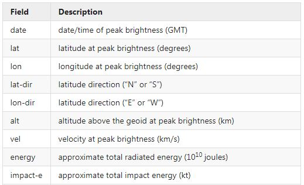

### Reading in the data

The `jsonlite` package has a `fromJSON()` function that allows us to convert JSON data to R objects. The R object that gets created depends on the structure of the JSON. We can see below that fireball data gets read in as a list of 4 objects.

```r
library(jsonlite)

fire <- fromJSON("https://ssd-api.jpl.nasa.gov/fireball.api")
str(fire)
```

```
## List of 4
##  $ signature:List of 2
##   ..$ source : chr "NASA/JPL Fireball Data API"
##   ..$ version: chr "1.0"
##  $ count    : chr "787"
##  $ fields   : chr [1:9] "date" "energy" "impact-e" "lat" ...
##  $ data     : chr [1:787, 1:9] "2019-05-26 10:07:55" "2019-05-25 06:44:04" "2019-05-22 15:16:49" "2019-05-21 13:21:35" ...
```

The column names and data get read in as two different items in the list. We need to create a data frame using this information. We can then convert the column types.

```r
library(tidyverse)

#store the column names
cols <- fire$fields

#create data frame
fire <- data.frame(fire$data,stringsAsFactors = FALSE)

#set column names
colnames(fire) <- cols

#convert to tibble
fire <- as_tibble(fire)

#convert column types
fire$date <- as.Date(fire$date)
numeric_cols <- c("energy","impact-e","lat","lon","alt","vel")
fire[,numeric_cols] <- sapply(fire[,numeric_cols], as.numeric)

head(fire)
```

```
## # A tibble: 6 x 9
##   date       energy `impact-e`   lat `lat-dir`   lon `lon-dir`   alt   vel
##   <date>      <dbl>      <dbl> <dbl> <chr>     <dbl> <chr>     <dbl> <dbl>
## 1 2019-05-26    4.2      0.14   56.6 N          25.3 W          24.4  17.5
## 2 2019-05-25    4.9      0.16   19.2 S          89.4 E          29.2  15.8
## 3 2019-05-22    9.5      0.290  10.8 N          37.3 W          32.6  NA
## 4 2019-05-21   65.6      1.6    38.8 S         138.  E          31.5  11.5
## 5 2019-05-19    3.3      0.11   23.6 S         133.  E          33.3  15.2
## 6 2019-05-12    2.1      0.076   6.2 N          57.1 W          NA    NA
```

## Exploratory Analysis

### Creating New Variables

To start exploring the data, a few additional variables would be helpful. Since we have the latitude and longitude, it would be nice to know more information on where these events occured. Thankfully, R has a package for that! The `revgeo` package allows you to do reverse geocoding, in which you input the coordinates and the geographical information is returned (city, state, etc.). For purposes of this analysis we only care about the country, which we can specify using the *item* argument. More information on the `revgeo` package can be found [on CRAN](https://cran.r-project.org/web/packages/revgeo/). Note this process can take a few minutes as it must run for each observation in our dataset.

```r
library(revgeo)

countries <- revgeo(longitude=fire$lon, latitude=fire$lat, provider = 'photon', output = 'hash',item='country')
countries <- countries$country

fire$country <- countries
```

It would also be helpful to extract the year and month from our date variable. We can also create a variable that tracks the direction of the fireball by combining our `lat-dir` and `lon-dir` variables.

```r
fire$year <- as.numeric(format(fire$date,'%Y'))
fire$month <- as.numeric(format(fire$date,'%m'))
fire$direction <- paste0(fire$`lat-dir`,fire$`lon-dir`)
```

Lastly, lets break up some of our numeric variables. We’ll create a function that makes this easy to do. The function `addPercentile()` takes a data frame, a variable, and a number indicating how many groups we want to break the variable into. It then returns the data frame with the new variable added.

```r
addPercentile <- function(df,var,n=4) {

  #make sure the input is valid
  if(!(any(class(df) %in% c("data.frame","tbl", "tbl_df")))){
    stop("Must supply a data frame/tibble")
  }

  if(!(var %in% names(df))){
    stop(paste("Variable",var,"not found in data frame"))
  }

  if(n%%1!=0){
    stop("Must supply an integer for the number of breaks")
  }

  #Use ntile() to create new groups
  df[,paste0(var,"_group")] <- paste("Group",ntile(df[[var]],n))

  return(df)
}
```

Now we can add the new grouping variables to our data frame, using the default of 4 which will give us quartiles. You can see that when we create a contingency table for the energy group, we have about 25% of the data falling in to each bucket as expected.

```r
library(knitr)

fire <- addPercentile(fire,"energy")
fire <- addPercentile(fire,"impact-e")
fire <- addPercentile(fire,"alt")
fire <- addPercentile(fire,"vel")

kable(prop.table(table(fire$energy_group)),col.names = c("Energy Group","%"))
```

| Energy Group | % |
| --- | --- |
| Group 1 | 0.2503177 |
| Group 2 | 0.2503177 |
| Group 3 | 0.2503177 |
| Group 4 | 0.2490470 |

### Data Tables

Now that we have the new variables, we can do some more exploratory analysis. Lets see how many fireball events we have by country and year/month, as well as the percentage of events in each direction.

```r
kable(table(fire$country),caption = "Fireballs by Country", col.names = c("Country","Freq"))
```

Fireballs by Country

| Country | Freq |
| --- | --- |
| Algeria | 2 |
| China | 9 |
| Country Not Found | 741 |
| Cyprus | 1 |
| Czech Republic | 1 |
| Finland | 1 |
| France | 4 |
| Hungary | 1 |
| India | 1 |
| Iran | 1 |
| Italy | 1 |
| Kazakhstan | 1 |
| Latvia | 1 |
| Macedonia | 1 |
| Nigeria | 1 |
| Poland | 3 |
| Romania | 2 |
| Russia | 5 |
| Slovakia | 1 |
| South Korea | 2 |
| Sweden | 1 |
| Switzerland | 1 |
| Taiwan | 1 |
| Turkey | 2 |
| Ukraine | 2 |

```r
kable(table(fire$year,fire$month),caption = "Fireballs by Year and Month")
```

Fireballs by Year and Month

|  | 1 | 2 | 3 | 4 | 5 | 6 | 7 | 8 | 9 | 10 | 11 | 12 |
| --- | --- | --- | --- | --- | --- | --- | --- | --- | --- | --- | --- | --- |
| 1988 | 0 | 0 | 0 | 1 | 0 | 0 | 0 | 0 | 0 | 0 | 0 | 0 |
| 1990 | 0 | 0 | 0 | 0 | 0 | 0 | 0 | 0 | 0 | 1 | 0 | 0 |
| 1991 | 0 | 0 | 0 | 0 | 0 | 0 | 0 | 0 | 0 | 1 | 0 | 0 |
| 1993 | 0 | 0 | 0 | 0 | 0 | 0 | 0 | 0 | 0 | 1 | 1 | 0 |
| 1994 | 0 | 1 | 0 | 0 | 1 | 2 | 0 | 1 | 1 | 3 | 2 | 2 |
| 1995 | 3 | 1 | 0 | 1 | 0 | 1 | 3 | 4 | 1 | 1 | 2 | 3 |
| 1996 | 2 | 2 | 5 | 0 | 2 | 1 | 2 | 7 | 0 | 6 | 2 | 4 |
| 1997 | 5 | 3 | 0 | 1 | 1 | 0 | 2 | 2 | 2 | 2 | 1 | 2 |
| 1998 | 2 | 0 | 2 | 0 | 0 | 0 | 1 | 2 | 2 | 1 | 2 | 1 |
| 1999 | 5 | 2 | 3 | 2 | 1 | 1 | 2 | 3 | 2 | 1 | 3 | 5 |
| 2000 | 2 | 2 | 3 | 2 | 3 | 8 | 4 | 3 | 3 | 1 | 3 | 2 |
| 2001 | 1 | 2 | 0 | 4 | 1 | 0 | 2 | 2 | 1 | 4 | 3 | 2 |
| 2002 | 2 | 2 | 7 | 2 | 0 | 4 | 2 | 3 | 1 | 2 | 4 | 0 |
| 2003 | 1 | 6 | 1 | 4 | 4 | 4 | 1 | 4 | 5 | 3 | 3 | 1 |
| 2004 | 4 | 2 | 2 | 4 | 3 | 6 | 6 | 1 | 2 | 4 | 2 | 3 |
| 2005 | 3 | 1 | 6 | 10 | 4 | 3 | 1 | 2 | 3 | 1 | 6 | 4 |
| 2006 | 5 | 3 | 1 | 3 | 4 | 1 | 2 | 5 | 4 | 5 | 1 | 3 |
| 2007 | 5 | 1 | 3 | 2 | 3 | 3 | 0 | 0 | 1 | 3 | 0 | 2 |
| 2008 | 2 | 5 | 1 | 2 | 4 | 2 | 5 | 3 | 1 | 3 | 4 | 3 |
| 2009 | 2 | 2 | 1 | 2 | 3 | 4 | 3 | 1 | 3 | 2 | 7 | 2 |
| 2010 | 1 | 3 | 5 | 3 | 0 | 3 | 2 | 1 | 5 | 2 | 5 | 4 |
| 2011 | 2 | 2 | 4 | 4 | 2 | 1 | 4 | 5 | 1 | 1 | 1 | 3 |
| 2012 | 2 | 4 | 3 | 4 | 4 | 1 | 2 | 3 | 4 | 5 | 2 | 2 |
| 2013 | 2 | 3 | 1 | 2 | 1 | 2 | 6 | 1 | 1 | 2 | 1 | 2 |
| 2014 | 3 | 2 | 3 | 0 | 4 | 2 | 2 | 3 | 2 | 4 | 5 | 3 |
| 2015 | 4 | 3 | 5 | 5 | 4 | 4 | 3 | 0 | 5 | 5 | 2 | 3 |
| 2016 | 2 | 4 | 2 | 4 | 4 | 3 | 2 | 3 | 2 | 1 | 3 | 2 |
| 2017 | 0 | 5 | 3 | 1 | 3 | 3 | 3 | 0 | 1 | 5 | 1 | 4 |
| 2018 | 4 | 5 | 0 | 5 | 3 | 3 | 3 | 2 | 5 | 3 | 4 | 2 |
| 2019 | 2 | 2 | 3 | 4 | 7 | 0 | 0 | 0 | 0 | 0 | 0 | 0 |

```r
kable(prop.table(table(fire$direction)),caption = "Percentage of Fireballs by Direction",col.names = c("Direction","%"))
```

Percentage of Fireballs by Direction

| Direction | % |
| --- | --- |
| NANA | 0.2325286 |
| NE | 0.1905972 |
| NW | 0.1842440 |
| SE | 0.2172808 |
| SW | 0.1753494 |

We can see that no country was found for the vast majority of our events. This is likely because most of them occured over the ocean and not over any specific country, or else no latitude/longitude information was recorded.

In regards to the date of observation, it is interesting to note that there were 7 fireball events recorded in May this year (2019), which is one of the highest monthly totals!

Lastly, we see that a roughly similar proportion of fireballs were moving in each direction, which is what we would expect if the direction is random (any fireballs where the direction was not recorded show as *NANA*).

### Charts

Now lets plot some graphs. Please note in the charts below that any events with missing data for a variable being plotted are removed from the data.

It might be that fireballs traveling at a higher velocity have a higher energy. We can look at this relationship using a boxplot. If we plot velocity on the y-axis, and the energy group on the x-axis, we see the following:

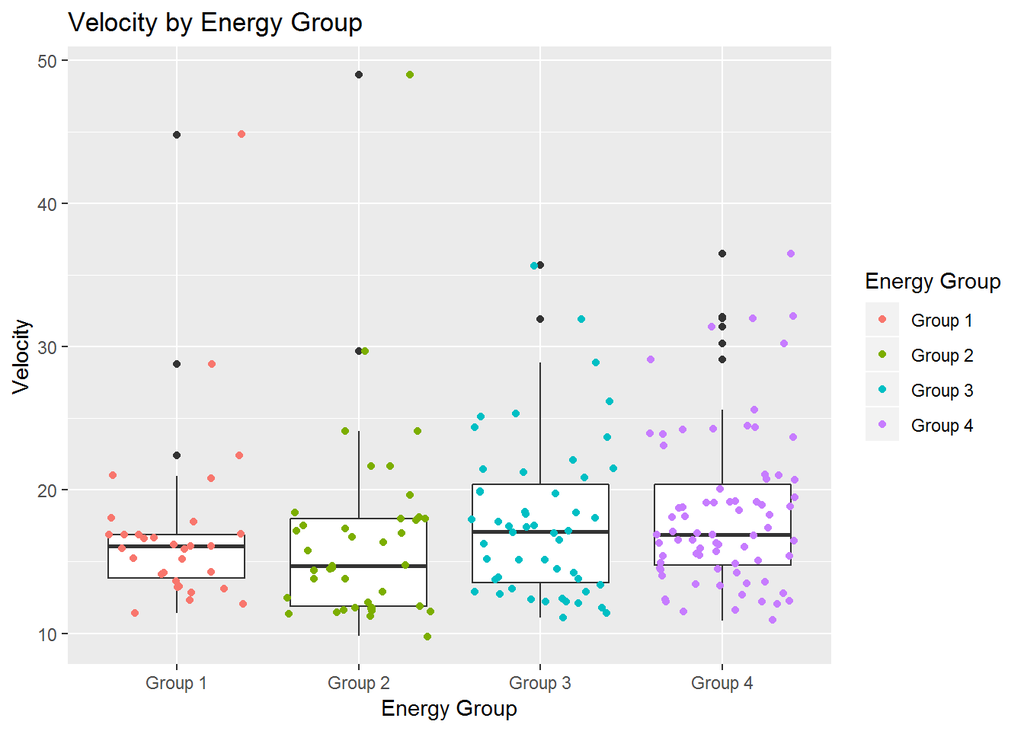

```r
g1 <- ggplot(fire, aes(x = energy_group, y = vel)) +
  geom_boxplot(fill = "white") +
  geom_point(aes(colour = energy_group),position = "jitter") +
  labs(x = "Energy Group",
       y = "Velocity",
       title = "Velocity by Energy Group",
       colour = "Energy Group")

print(g1)
```

While the median velocity for energy groups 3 and 4 is slightly higher than for groups 1 and 2, there is a large amount of overlap in all of the boxes, so it doesn’t appear that there is much of a relationship.

We can also take a look and see if the fireballs moving in a particular direction are more likely to be observed during a certain month of the year (possibly due to the rotation of the earth).

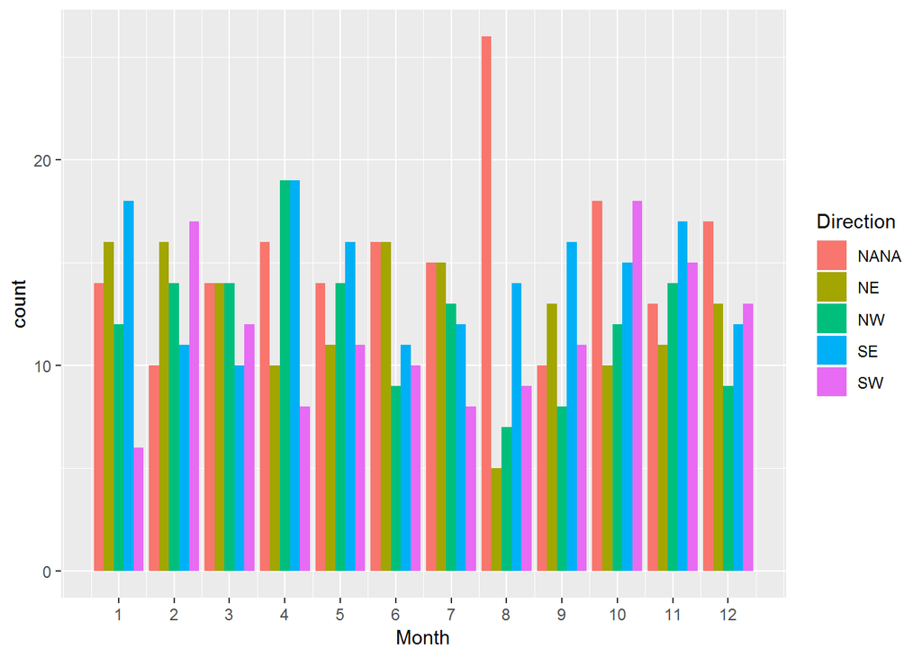

```r
bar <- ggplot(data = fire, aes(x = month)) +
  geom_bar(aes(fill = direction),position = "dodge") +
  labs(x = "Month", fill = 'Direction') +
  scale_x_continuous("Month",breaks=seq(1,12,1))

plot(bar)
```

There doesn’t appear to be much of a relationship in the chart above either.

It is possible that fireballs at a higher altitude have more velocity since there is less resistance from the atmosphere. We can look at this relationship using a scatterplot. We can also check if there is a relationship between altitude and energy, by plotting a scatterplot of altitude vs. energy for each energy group.

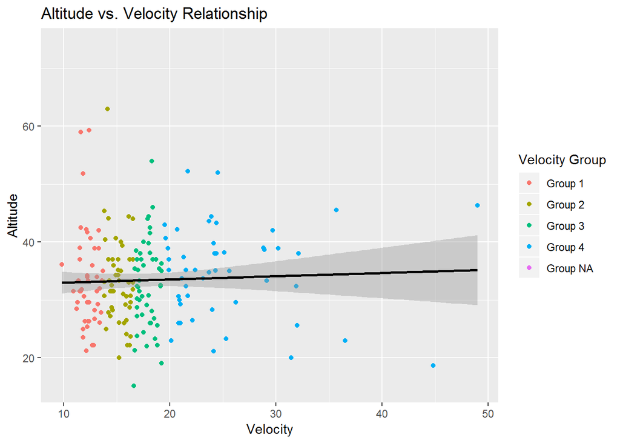

```r
g2 <- ggplot(fire, aes(x = vel, y = alt)) +
  geom_point((aes(colour = vel_group))) +
  geom_smooth(method="lm",colour="black") +
  labs(x = "Velocity",
       y = "Altitude",
       title = "Altitude vs. Velocity Relationship",
       colour = "Velocity Group")

print(g2)
```

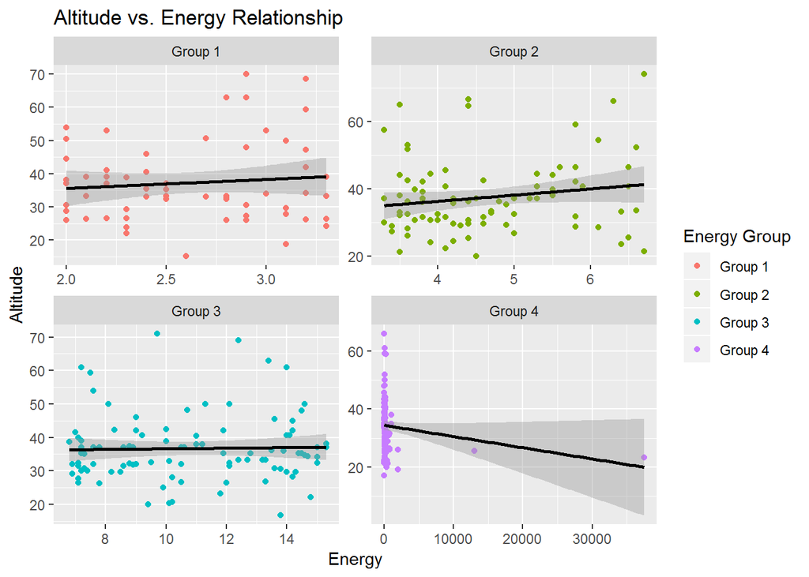

```r
g3 <- ggplot(fire, aes(x = energy, y = alt)) +
  geom_point((aes(colour = energy_group))) +
  facet_wrap(~ energy_group, scales = "free") +
  geom_smooth(method="lm",colour="black") +
  labs(x = "Energy",
       y = "Altitude",
       title = "Altitude vs. Energy Relationship",
       colour = "Energy Group")

print(g3)
```

There doesn’t appear to be a strong relationship in either of these charts.

Lastly, let’s take a look at Energy vs. Impact energy. There is likely a relationship between these two variables, but it would be useful to know whether it is a linear relationship or some other type of relationship. We can facet the chart based on the impact group to see if the relationship changes throughout the range of data.

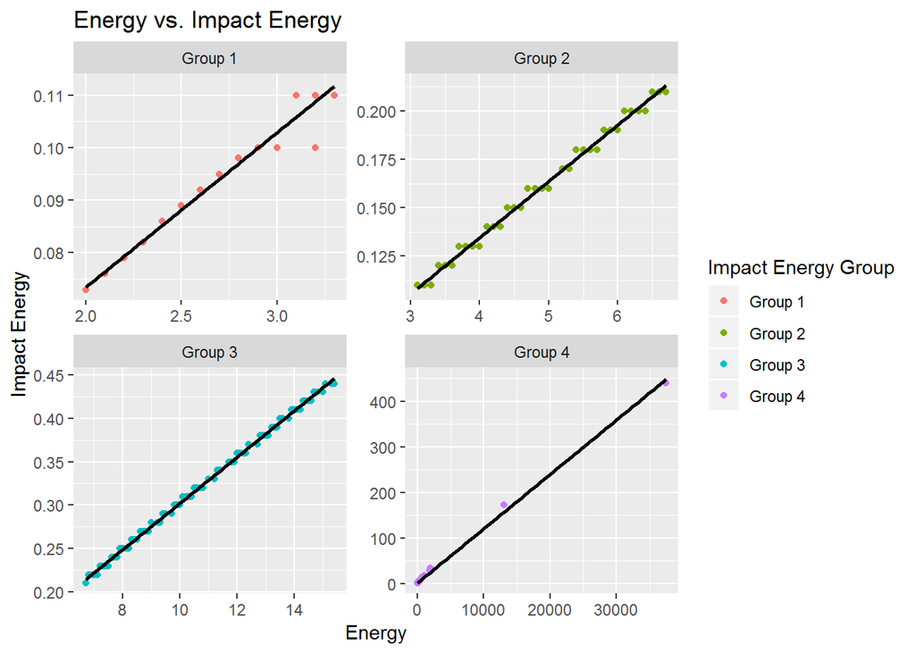

```r
g4 <- ggplot(fire, aes(x = energy, y = `impact-e`)) +
  geom_point((aes(colour = `impact-e_group`))) +
  geom_smooth(method="lm",colour="black") +
  facet_wrap(~ `impact-e_group`,scales = "free") +
  labs(x = "Energy",
       y = "Impact Energy",
       title = "Energy vs. Impact Energy",
       colour = "Impact Energy Group")

print(g4)
```

We can see there is a strong linear relationship between energy and impact energy across the different groups.

## Conclusion

In this vignette we have demonstrated the use of the `jsonlite` package to read in JSON data. We have read in data concerning observed fireball events, done some data wrangling with various R functions (including our own custom defined function), and performed an exploratory analysis of the data. While there does not appear to be too many relationships within our data set, we believe further analysis would be warranted in examinging the relationship between altitude and energy, as the slope does appear to change slightly across the different energy groups. Examining this relationship further will help researchers better understand these fireball events.